# Notebook

## Python Code

### 31_create_volcanic_eruption_timeseries.ipynb

**This script enriches the volcano and eruption datasets with additional parameters and creates the final timeseries for further usage.** The main parts of the routines were developed in previous courses at the University of London by the same author (Mohr, 2021, 2023, 2024a) and have been further refined to meet the needs of this MSc thesis project/research. However, the code has been updated to comply with the latest requirements and package interdependencies. Some comments will be included in this Jupyter Notebook, and the code contains several inline comments. For details on the project/research itself, refer to the appropriate document.

#### References (for this script)

*Mohr, S. (2021) Regional Spatial Clusters of Earthquakes at the Pacific Ring of Fire: Analysing Data from the USGS ANSS ComCat and Building Regional Spatial Clusters. DSM020, Python, examined coursework cw1. University of London.*

*Mohr, S. (2023) Clustering of Earthquakes on a Worldwide Scale with the Help of Big Data Machine Learning Methods. DSM010, Big Data, examined coursework cw2. University of London.*

*Mohr, S. (2024a) Comparing Different Tectonic Setups Considering Publicly Available Basic Earthquake’s Data. DSM050, Data Visualisation, examined coursework cw1. University of London.*

#### History

```
250105 Generation from previous courseworks at the UoL, setup basic logging, read dataset,
       save dataset, add column EruptedVolume
250110 Completely adopt new 30_* design with multivariate timeseries, added info about ongoing or active eruptions
       (and there is no need to change any start- or end-dates), check temporal fitting to timespan,
       add total erupted volume per day, add total number of active eruptions per day, improved figure for all
       freq of all timeseries, moved analyze_outliers
250120 Switching to parameters.py, adding selectable cluster directory, changing all directories, using now
       *_spatially_selected.csv data from the cluster directory
250125 Integrating new version of save_dataset
```

#### Todo

```
./.
```

## Preparing the environment

### System information

```python
# which python installation and version are we using here?
print('\n******* Python Info ***********')
!which python
!python --version

# show some CPU and RAM info
print('\n******* CPU Info ***********')
!lscpu
print('\n******* RAM Info (in GB) ***********')
!free -g
```

[output not shown]

[output cut: 24 more lines]

[output not shown]

```python
# show installed packages and versions
!pip freeze
```

[output not shown]

[output cut: 203 more lines]

[output not shown]

### Setting PATH correctly

```python
# there is somewhere a PATH-error on LENA for a while
# adding my packages path to the PATH environment

import sys
sys.path.append("/home/smohr001/.local/lib/python3.8/site-packages")
sys.path
```

```
['/home/smohr001/thesis',
 '/usr/lib/python38.zip',
 '/usr/lib/python3.8',
 '/usr/lib/python3.8/lib-dynload',
 '',
 '/opt/jupyterhub/lib/python3.8/site-packages',
 '/opt/jupyterhub/lib/python3.8/site-packages/IPython/extensions',
 '/home/smohr001/.ipython',
 '/home/smohr001/.local/lib/python3.8/site-packages',
 '/home/smohr001/.local/lib/python3.8/site-packages',
 '/home/smohr001/.local/lib/python3.8/site-packages']
```

### Loading libraries

```python
# importing standard libraries
import sys
import os
import warnings
import datetime
import time
import math
import numpy as np
import pandas as pd
import matplotlib.pyplot as plt
import seaborn as sns
import random
import logging
from IPython.display import display, Javascript

# importing shared procedures for this procect (needs to be a simple .py file)
%run shared_procedures.py

# importing additional libraries
import geopandas as gpd
from shapely.geometry import Point
from shapely import wkt

# get info about installed and used versions of some important (deep learning) libraries
print("Some important installed libraries:\n")
print(f"Pandas version: {pd.__version__}")
print(f"Numpy version: {np.__version__}")
print(f"Seaborn version: {sns.__version__}")
```

```
Some important installed libraries:

Pandas version: 1.4.1
Numpy version: 1.22.2
Seaborn version: 0.13.2
```

### Setting the script environment

```python
# import the parameters (foreced to reload)
import parameters
import importlib
importlib.reload(parameters)

# print all loaded parameters from the Python file
print("Loaded Parameters:\n")
for key in dir(parameters):
    if not key.startswith("__"):
        value = getattr(parameters, key)
        print(f"parameters.{key} = {value}")
```

```
Loaded Parameters:

parameters.buffer_size_km = 1000
parameters.data_dir = data/scope/reclustered_1000
parameters.data_dir_raw = data
parameters.data_ts_dir = data/scope/reclustered_1000
parameters.scope_id = gvp_reclustered_1000
```

```python
# show all matplotlib graphs inline
%matplotlib inline

# setting format to JPG for easy copy & paste for figures
# for high quality outputs choose 'svg'
%config InlineBackend.figure_format = 'jpg'

# adjust display settings to show 20 rows as a standard
display_max_rows = 20
pd.set_option('display.max_rows', display_max_rows)

# disable warnings (activate after developing the complete code)
warnings.filterwarnings('ignore')

# set script (ipynb notebook) name (e.g. for logging)
script_name = "31_create_volcanic_eruption_timeseries.ipynb"

# start parameterized logging
setup_logging(logfile_dir = "log",
              logfile_name = "30_create_timeseries.log",
              log_level = logging.INFO,
              script_name = script_name
             )

# set data directory
if(parameters.data_dir_raw):
    data_dir_raw = parameters.data_dir_raw
else:
    data_dir_raw = "data"
logging.info(f"{script_name}: Set raw data directory to './{data_dir_raw}'.")

if(parameters.data_dir):
    data_dir = parameters.data_dir
else:
    data_dir = "data"
logging.info(f"{script_name}: Set scope data directory to './{data_dir}'.")

if(parameters.data_ts_dir):
    data_ts_dir = parameters.data_ts_dir
else:
    data_ts_dir = "data/timeseries"
logging.info(f"{script_name}: Set scope timeseries data directory to './{data_ts_dir}'.")
```

```
2025-01-26 21:15:22,953 - INFO - Starting script '31_create_volcanic_eruption_timeseries.ipynb'.
2025-01-26 21:15:22,955 - INFO - Set loglevel to INFO.
2025-01-26 21:15:22,955 - INFO - 31_create_volcanic_eruption_timeseries.ipynb: Set raw data directory to './data'.
2025-01-26 21:15:22,956 - INFO - 31_create_volcanic_eruption_timeseries.ipynb: Set scope data directory to './data/scope/reclustered_1000'.
2025-01-26 21:15:22,957 - INFO - 31_create_volcanic_eruption_timeseries.ipynb: Set scope timeseries data directory to './data/scope/reclustered_1000'.
```

```python
# set fixed seed for reproducibility
reset_random_seeds(script_name=script_name)
```

```
2025-01-26 21:15:22,961 - INFO - 31_create_volcanic_eruption_timeseries.ipynb: Seeding random generators with seed=654321.
```

## Loading data

```python
def list_subdirectories(directory, prefix="cluster_"):
    # Filter subdirectories with the given prefix
    return [name for name in os.listdir(directory) if os.path.isdir(os.path.join(directory, name)) and name.startswith(prefix)]

def choose_subdirectory(directory):
    subdirs = list_subdirectories(directory)

    if not subdirs:
        print(f"No subdirectories starting with 'cluster_' were found in {directory}.")
        return None

    # Print the list of subdirectories with indices
    print("Available subdirectories:")
    for i, subdir in enumerate(subdirs):
        print(f"{i + 1}: {subdir}")

    # Prompt the user to select a subdirectory
    while True:
        try:
            choice = int(input("Enter the number of the subdirectory you want to choose: "))
            if 1 <= choice <= len(subdirs):
                return subdirs[choice - 1]
            else:
                print("Invalid choice. Please enter a number from the list.")
        except ValueError:
            print("Invalid input. Please enter a number.")

# set individual clusterdir for saving
selected_subdir = choose_subdirectory(data_dir)
data_dir_cluster = os.path.join(data_dir, selected_subdir)
data_ts_dir_cluster = os.path.join(data_ts_dir, selected_subdir)
logging.info(f"{script_name}: Set cluster data directory to './{data_dir_cluster}'.")
logging.info(f"{script_name}: Set cluster timeseries data directory to './{data_ts_dir_cluster}'.")

# load selected datasets
volcanoes_selected = load_dataset(data_file="volcanoes_spatially_selected.csv", data_dir=data_ts_dir_cluster)
eruptions_selected = load_dataset(data_file="eruptions_spatially_selected.csv", data_dir=data_ts_dir_cluster)
```

```
Available subdirectories:
1: cluster_Cluster_4
2: cluster_Cluster_3
3: cluster_Cluster_0
4: cluster_Cluster_5
5: cluster_Cluster_6
6: cluster_Cluster_1
7: cluster_Cluster_2
Enter the number of the subdirectory you want to choose: 3
```

```
2025-01-26 21:15:23,684 - INFO - 31_create_volcanic_eruption_timeseries.ipynb: Set cluster data directory to './data/scope/reclustered_1000/cluster_Cluster_0'.
2025-01-26 21:15:23,685 - INFO - 31_create_volcanic_eruption_timeseries.ipynb: Set cluster timeseries data directory to './data/scope/reclustered_1000/cluster_Cluster_0'.
2025-01-26 21:15:23,694 - INFO - load_dataset: Data loaded successfully from 'data/scope/reclustered_1000/cluster_Cluster_0/volcanoes_spatially_selected.csv'.
2025-01-26 21:15:23,700 - INFO - load_dataset: Data loaded successfully from 'data/scope/reclustered_1000/cluster_Cluster_0/eruptions_spatially_selected.csv'.
```

## Statistics and information

```python
# infos of the datasets
print("Volcanoes")
pd.set_option('display.max_rows', None)
print("\nShape:\n" + str(volcanoes_selected.shape))
print("\nColumns and DataTypes:\n" + str(volcanoes_selected.dtypes))
pd.set_option('display.max_rows', 20)
display(volcanoes_selected)
logging.info(f"{script_name}: Used dataset is 'volcanoes_selected' with {volcanoes_selected.shape}.")

print("Eruptions")
pd.set_option('display.max_rows', None)
print("\nShape:\n" + str(eruptions_selected.shape))
print("\nColumns and DataTypes:\n" + str(eruptions_selected.dtypes))
pd.set_option('display.max_rows', 20)
display(eruptions_selected)
logging.info(f"{script_name}: Used dataset is 'eruptions_selected' with {eruptions_selected.shape}.")
```

```
Volcanoes

Shape:
(38, 18)

Columns and DataTypes:
Unnamed: 0                int64
Volcano_Number            int64
geo_x                   float64
geo_y                   float64
Volcano_Name             object
Primary_Volcano_Type     object
Country                  object
Region                   object
Latitude                float64
Longitude               float64
Elevation                 int64
Tectonic_Setting         object
Evidence_Category        object
Major_Rock_Type          object
Erupting                   bool
Last_Activity_Year        int64
geometry                 object
region_name              object
dtype: object
```

|  | Unnamed: 0 | Volcano_Number | geo_x | geo_y | Volcano_Name | Primary_Volcano_Type | Country | Region | Latitude | Longitude | Elevation | Tectonic_Setting | Evidence_Category | Major_Rock_Type | Erupting | Last_Activity_Year | geometry | region_name |
| --- | --- | --- | --- | --- | --- | --- | --- | --- | --- | --- | --- | --- | --- | --- | --- | --- | --- | --- |
| 0 | 47 | 272020 | 123.1300 | 10.4096 | Kanlaon | Stratovolcano(es) | Philippines | Western Pacific Volcanic Regions | 10.4096 | 123.1300 | 2422 | Subduction zone / Continental crust (> 25 km) | Eruption Observed | Andesite / Basaltic Andesite | True | 2017 | POINT (123.13 10.4096) | Cluster_0 |
| 1 | 48 | 273010 | 124.0560 | 12.7690 | Bulusan | Stratovolcano(es) | Philippines | Western Pacific Volcanic Regions | 12.7690 | 124.0560 | 1535 | Subduction zone / Continental crust (> 25 km) | Eruption Observed | Andesite / Basaltic Andesite | True | 2017 | POINT (124.056 12.769) | Cluster_0 |
| 2 | 49 | 273030 | 123.6850 | 13.2570 | Mayon | Stratovolcano(es) | Philippines | Western Pacific Volcanic Regions | 13.2570 | 123.6850 | 2462 | Subduction zone / Continental crust (> 25 km) | Eruption Observed | Andesite / Basaltic Andesite | True | 2019 | POINT (123.685 13.257) | Cluster_0 |
| 3 | 50 | 273070 | 120.9975 | 14.0106 | Taal | Caldera | Philippines | Western Pacific Volcanic Regions | 14.0106 | 120.9975 | 311 | Subduction zone / Continental crust (> 25 km) | Eruption Observed | Andesite / Basaltic Andesite | True | 1977 | POINT (120.9975 14.0106) | Cluster_0 |
| 4 | 51 | 273083 | 120.3500 | 15.1300 | Pinatubo | Stratovolcano(es) | Philippines | Western Pacific Volcanic Regions | 15.1300 | 120.3500 | 1486 | Subduction zone / Continental crust (> 25 km) | Eruption Observed | Dacite | True | 1993 | POINT (120.35 15.13) | Cluster_0 |
| ... | ... | ... | ... | ... | ... | ... | ... | ... | ... | ... | ... | ... | ... | ... | ... | ... | ... | ... |
| 33 | 83 | 284141 | 145.0300 | 20.4200 | Ahyi | Stratovolcano(es) | United States | Northwest Pacific Volcanic Regions | 20.4200 | 145.0300 | -75 | Subduction zone / Crustal thickness unknown | Eruption Dated | Andesite / Basaltic Andesite | True | 2014 | POINT (145.03 20.42) | Cluster_0 |
| 34 | 84 | 284170 | 145.8000 | 18.1300 | Pagan | Stratovolcano(es) | United States | Northwest Pacific Volcanic Regions | 18.1300 | 145.8000 | 570 | Subduction zone / Crustal thickness unknown | Eruption Observed | Basalt / Picro-Basalt | True | 2012 | POINT (145.8 18.13) | Cluster_0 |
| 35 | 85 | 284202 | 145.5720 | 15.6050 | Ruby | Stratovolcano(es) | United States | Northwest Pacific Volcanic Regions | 15.6050 | 145.5720 | -174 | Subduction zone / Crustal thickness unknown | Eruption Observed | Basalt / Picro-Basalt | True | 1995 | POINT (145.572 15.605) | Cluster_0 |
| 36 | 86 | 284200 | 145.6700 | 16.3500 | Anatahan | Stratovolcano(es) | United States | Northwest Pacific Volcanic Regions | 16.3500 | 145.6700 | 790 | Subduction zone / Crustal thickness unknown | Eruption Observed | Andesite / Basaltic Andesite | True | 2008 | POINT (145.67 16.35) | Cluster_0 |
| 37 | 199 | 284193 | 145.7800 | 16.5800 | South Sarigan Seamount | Stratovolcano(es) | United States | Northwest Pacific Volcanic Regions | 16.5800 | 145.7800 | -184 | Subduction zone / Crustal thickness unknown | Eruption Observed | unknown | True | 2010 | POINT (145.78 16.58) | Cluster_0 |

38 rows × 18 columns

```
2025-01-26 21:15:23,730 - INFO - 31_create_volcanic_eruption_timeseries.ipynb: Used dataset is 'volcanoes_selected' with (38, 18).
```

```
Eruptions

Shape:
(219, 14)

Columns and DataTypes:
Unnamed: 0              int64
Volcano_Number          int64
Eruption_Number         int64
Activity_Type          object
ExplosivityIndexMax     int64
StartEvidenceMethod    object
StartDateYear           int64
StartDateMonth          int64
StartDateDay            int64
EndDateYear             int64
EndDateMonth            int64
EndDateDay              int64
StartDate              object
EndDate                object
dtype: object
```

|  | Unnamed: 0 | Volcano_Number | Eruption_Number | Activity_Type | ExplosivityIndexMax | StartEvidenceMethod | StartDateYear | StartDateMonth | StartDateDay | EndDateYear | EndDateMonth | EndDateDay | StartDate | EndDate |
| --- | --- | --- | --- | --- | --- | --- | --- | --- | --- | --- | --- | --- | --- | --- |
| 0 | 53 | 283170 | 17913 | Confirmed Eruption | 1 | Observations: Reported | 1996 | 9 | 1 | 1996 | 9 | 1 | 1996-09-01 | 1996-09-01 |
| 1 | 54 | 283180 | 17937 | Confirmed Eruption | 1 | Observations: Reported | 1977 | 12 | 7 | 1977 | 12 | 7 | 1977-12-07 | 1977-12-07 |
| 2 | 109 | 284010 | 18241 | Confirmed Eruption | 1 | Observations: Reported | 1974 | 2 | 28 | 1974 | 6 | 20 | 1974-02-28 | 1974-06-20 |
| 3 | 110 | 284010 | 18242 | Confirmed Eruption | 3 | Observations: Reported | 1986 | 11 | 15 | 1986 | 12 | 18 | 1986-11-15 | 1986-12-18 |
| 4 | 111 | 284010 | 18243 | Confirmed Eruption | 2 | Observations: Reported | 1987 | 11 | 16 | 1988 | 1 | 27 | 1987-11-16 | 1988-01-27 |
| ... | ... | ... | ... | ... | ... | ... | ... | ... | ... | ... | ... | ... | ... | ... |
| 214 | 1218 | 284040 | 18276 | Confirmed Eruption | 1 | Observations: Reported | 2005 | 4 | 12 | 2005 | 5 | 18 | 2005-04-12 | 2005-05-18 |
| 215 | 1219 | 284040 | 18277 | Confirmed Eruption | 1 | Observations: Reported | 2006 | 2 | 17 | 2006 | 2 | 17 | 2006-02-17 | 2006-02-17 |
| 216 | 1220 | 284040 | 18278 | Confirmed Eruption | 1 | Observations: Reported | 2006 | 8 | 23 | 2006 | 8 | 23 | 2006-08-23 | 2006-08-23 |
| 217 | 1221 | 284040 | 18272 | Confirmed Eruption | 3 | Observations: Reported | 1983 | 10 | 3 | 1983 | 10 | 4 | 1983-10-03 | 1983-10-04 |
| 218 | 1222 | 284070 | 18323 | Confirmed Eruption | 2 | Observations: Reported | 1970 | 1 | 29 | 1970 | 6 | 16 | 1970-01-29 | 1970-06-16 |

219 rows × 14 columns

```
2025-01-26 21:15:23,740 - INFO - 31_create_volcanic_eruption_timeseries.ipynb: Used dataset is 'eruptions_selected' with (219, 14).
```

## Enriching with volcanic parameters

```python
# make a deep copy of the datasets for further processing
volcanoes_enriched = volcanoes_selected.copy()
eruptions_enriched = eruptions_selected.copy()
logging.info(f"{script_name}: Used dataset is 'volcanoes_enriched' with {volcanoes_selected.shape}.")
logging.info(f"{script_name}: Used dataset is 'eruptions_enriched' with {eruptions_selected.shape}.")
```

```
2025-01-26 21:15:23,745 - INFO - 31_create_volcanic_eruption_timeseries.ipynb: Used dataset is 'volcanoes_enriched' with (38, 18).
2025-01-26 21:15:23,746 - INFO - 31_create_volcanic_eruption_timeseries.ipynb: Used dataset is 'eruptions_enriched' with (219, 14).
```

```python
# show all column names
print("Volcanoes column names")
print(volcanoes_enriched.columns.tolist())

print("\nEruptions column names")
print(eruptions_enriched.columns.tolist())
```

```
Volcanoes column names
['Unnamed: 0', 'Volcano_Number', 'geo_x', 'geo_y', 'Volcano_Name', 'Primary_Volcano_Type', 'Country', 'Region', 'Latitude', 'Longitude', 'Elevation', 'Tectonic_Setting', 'Evidence_Category', 'Major_Rock_Type', 'Erupting', 'Last_Activity_Year', 'geometry', 'region_name']

Eruptions column names
['Unnamed: 0', 'Volcano_Number', 'Eruption_Number', 'Activity_Type', 'ExplosivityIndexMax', 'StartEvidenceMethod', 'StartDateYear', 'StartDateMonth', 'StartDateDay', 'EndDateYear', 'EndDateMonth', 'EndDateDay', 'StartDate', 'EndDate']
```

### Setting correct datatypes

```python
# define (target) data types for volcanoes
set_types_volcanoes = {'Volcano_Number': 'int64',
                       'Volcano_Name': 'object',
                       'Primary_Volcano_Type': 'object',
                       'Last_Activity_Year': 'int64',
                       'Country': 'object',
                       'Region': 'object',
                       'Latitude': 'float64',
                       'Longitude': 'float64',
                       'Elevation': 'int64',
                       'Tectonic_Setting': 'object',
                       'Evidence_Category': 'object',
                       'Major_Rock_Type': 'object'
                      }

# check data types for volcanoes
check_data_types_of_dataframe(volcanoes_enriched, set_types_volcanoes)
```

```
Checking datatypes (no output means nothing to correct):
```

```python
# define (target) data types for eruptions
set_types_eruptions = {'Volcano_Number': 'int64',
                       'Eruption_Number': 'int64',
                       'Activity_Type': 'object',
                       'ExplosivityIndexMax': 'int64',
                       'StartEvidenceMethod': 'object',
                       'StartDateYear': 'int64',
                       'StartDateMonth': 'int64',
                       'StartDateDay': 'int64',
                       'EndDateYear': 'int64',
                       'EndDateMonth': 'int64',
                       'EndDateDay': 'int64',
                       'StartDate': 'datetime64[ns]',
                       'EndDate': 'datetime64[ns]'
                      }

## check data types
check_data_types_of_dataframe(eruptions_enriched, set_types_eruptions)
```

```
Checking datatypes (no output means nothing to correct):

StartDate: object --> datetime64[ns]
EndDate: object --> datetime64[ns]
```

```python
# convert datatypes
print("Volcanoes")
volcanoes_enriched = convert_data_types_of_dataframe(volcanoes_enriched, set_types_volcanoes)

# handling of spatial geometry point information (pre-applying the right format)
print("Column 'geometry' pre-converted with WKT information (prepared for POINT conversion).")
volcanoes_enriched['geometry'] = volcanoes_enriched['geometry'].apply(wkt.loads)

print("\nEruptions")
eruptions_enriched = convert_data_types_of_dataframe(eruptions_enriched, set_types_eruptions)
```

```
Volcanoes
Column 'Volcano_Number' converted to int64.
Column 'Volcano_Name' converted to object.
Column 'Primary_Volcano_Type' converted to object.
Column 'Last_Activity_Year' converted to int64.
Column 'Country' converted to object.
Column 'Region' converted to object.
Column 'Latitude' converted to float64.
Column 'Longitude' converted to float64.
Column 'Elevation' converted to int64.
Column 'Tectonic_Setting' converted to object.
Column 'Evidence_Category' converted to object.
Column 'Major_Rock_Type' converted to object.
Column 'geometry' pre-converted with WKT information (prepared for POINT conversion).

Eruptions
Column 'Volcano_Number' converted to int64.
Column 'Eruption_Number' converted to int64.
Column 'Activity_Type' converted to object.
Column 'ExplosivityIndexMax' converted to int64.
Column 'StartEvidenceMethod' converted to object.
Column 'StartDateYear' converted to int64.
Column 'StartDateMonth' converted to int64.
Column 'StartDateDay' converted to int64.
Column 'EndDateYear' converted to int64.
Column 'EndDateMonth' converted to int64.
Column 'EndDateDay' converted to int64.
Column 'StartDate' converted to datetime64[ns].
Column 'EndDate' converted to datetime64[ns].
```

### Ejecta

For comparing the cumulative sums of erupted material (ejecta), a conversion of the ExplosivityIndexMax (VEI) is needed, according to the following table (Lockwood, Hazlett and La Cruz Reyna, 2022; Newhall and Self, 1982).

| VEI | Explanation | Volume (range) | Volume (mean) |
| --- | --- | --- | --- |
| 0 | Non-explosive | $$<10^4$$ | $$10^3$$ |
| 1 | Small | $$10^4-10^6$$ | $$10^5$$ |
| 2 | Moderate | $$10^6-10^7$$ | $$5*10^{6}$$ |
| 3 | Maderate-Large | $$10^7-10^8$$ | $$5*10^{7}$$ |
| 4 | Large | $$10^8-10^9$$ | $$5*10^{8}$$ |
| 5 | Very Large | $$10^9-10^{10}$$ | $$5*10^{9}$$ |
| 6 | Very Large | $$10^{10}-10^{11}$$ | $$5*10^{10}$$ |
| 7 | Very Large | $$10^{11}-10^{12}$$ | $$5*10^{11}$$ |
| 9 | Very Large | $$>10^{12}$$ | $$10^{13}$$ |

```python
# build a mapping table according to the previous table.
volume_mean_mapping = {
    0: 10**3,
    1: 10**5,
    2: 5 * 10**6,
    3: 5 * 10**7,
    4: 5 * 10**8,
    5: 5 * 10**9,
    6: 5 * 10**10,
    7: 5 * 10**11,
    9: 10**13
}

# calculate the erupted volume and add it to the dataframe
eruptions_enriched['EruptedVolume'] = eruptions_enriched['ExplosivityIndexMax'].map(volume_mean_mapping)

# display results
display(eruptions_enriched[['ExplosivityIndexMax','EruptedVolume']])
```

|  | ExplosivityIndexMax | EruptedVolume |
| --- | --- | --- |
| 0 | 1 | 100000 |
| 1 | 1 | 100000 |
| 2 | 1 | 100000 |
| 3 | 3 | 50000000 |
| 4 | 2 | 5000000 |
| ... | ... | ... |
| 214 | 1 | 100000 |
| 215 | 1 | 100000 |
| 216 | 1 | 100000 |
| 217 | 3 | 50000000 |
| 218 | 2 | 5000000 |

219 rows × 2 columns

### Calculate the erupted volume per day per eruption

```python
# calculate the number of days each eruption lasts
eruptions_enriched['DurationDays'] = (eruptions_enriched['EndDate'] - eruptions_enriched['StartDate']).dt.days + 1

# avoid division by zero for any invalid durations
eruptions_enriched['DurationDays'] = eruptions_enriched['DurationDays'].clip(lower=1)

# calculate the erupted volume per day
eruptions_enriched['DailyEruptedVolume'] = eruptions_enriched['EruptedVolume'] / eruptions_enriched['DurationDays']

# display the updated dataframe
display(eruptions_enriched[['DurationDays','DailyEruptedVolume']])
```

|  | DurationDays | DailyEruptedVolume |
| --- | --- | --- |
| 0 | 1 | 1.000000e+05 |
| 1 | 1 | 1.000000e+05 |
| 2 | 113 | 8.849558e+02 |
| 3 | 34 | 1.470588e+06 |
| 4 | 73 | 6.849315e+04 |
| ... | ... | ... |
| 214 | 37 | 2.702703e+03 |
| 215 | 1 | 1.000000e+05 |
| 216 | 1 | 1.000000e+05 |
| 217 | 2 | 2.500000e+07 |
| 218 | 139 | 3.597122e+04 |

219 rows × 2 columns

## Build timeseries

### Statistics and information

```python
# infos of the datasets
print("Volcanoes")
print("=========")
pd.set_option('display.max_rows', None)
print("\nShape:\n" + str(volcanoes_enriched.shape))
print("\nColumns and DataTypes:\n" + str(volcanoes_enriched.dtypes))
pd.set_option('display.max_rows', display_max_rows)
print("\nDataset:")
display(volcanoes_enriched)

print("Eruptions")
print("=========")
pd.set_option('display.max_rows', None)
print("\nShape:\n" + str(eruptions_enriched.shape))
print("\nColumns and DataTypes:\n" + str(eruptions_enriched.dtypes))
pd.set_option('display.max_rows', display_max_rows)
print("\nDataset:")
display(eruptions_enriched)

# log the dataset usage
logging.info(f"{script_name}: Used dataset for building timeseries is 'volcanoes_enriched' with {volcanoes_enriched.shape}.")
logging.info(f"{script_name}: Used dataset for building timeseries is 'eruptions_enriched' with {eruptions_enriched.shape}.")
```

```
Volcanoes
=========

Shape:
(38, 18)

Columns and DataTypes:
Unnamed: 0                int64
Volcano_Number            int64
geo_x                   float64
geo_y                   float64
Volcano_Name             object
Primary_Volcano_Type     object
Country                  object
Region                   object
Latitude                float64
Longitude               float64
Elevation                 int64
Tectonic_Setting         object
Evidence_Category        object
Major_Rock_Type          object
Erupting                   bool
Last_Activity_Year        int64
geometry                 object
region_name              object
dtype: object

Dataset:
```

|  | Unnamed: 0 | Volcano_Number | geo_x | geo_y | Volcano_Name | Primary_Volcano_Type | Country | Region | Latitude | Longitude | Elevation | Tectonic_Setting | Evidence_Category | Major_Rock_Type | Erupting | Last_Activity_Year | geometry | region_name |
| --- | --- | --- | --- | --- | --- | --- | --- | --- | --- | --- | --- | --- | --- | --- | --- | --- | --- | --- |
| 0 | 47 | 272020 | 123.1300 | 10.4096 | Kanlaon | Stratovolcano(es) | Philippines | Western Pacific Volcanic Regions | 10.4096 | 123.1300 | 2422 | Subduction zone / Continental crust (> 25 km) | Eruption Observed | Andesite / Basaltic Andesite | True | 2017 | POINT (123.13 10.4096) | Cluster_0 |
| 1 | 48 | 273010 | 124.0560 | 12.7690 | Bulusan | Stratovolcano(es) | Philippines | Western Pacific Volcanic Regions | 12.7690 | 124.0560 | 1535 | Subduction zone / Continental crust (> 25 km) | Eruption Observed | Andesite / Basaltic Andesite | True | 2017 | POINT (124.056 12.769) | Cluster_0 |
| 2 | 49 | 273030 | 123.6850 | 13.2570 | Mayon | Stratovolcano(es) | Philippines | Western Pacific Volcanic Regions | 13.2570 | 123.6850 | 2462 | Subduction zone / Continental crust (> 25 km) | Eruption Observed | Andesite / Basaltic Andesite | True | 2019 | POINT (123.685 13.257) | Cluster_0 |
| 3 | 50 | 273070 | 120.9975 | 14.0106 | Taal | Caldera | Philippines | Western Pacific Volcanic Regions | 14.0106 | 120.9975 | 311 | Subduction zone / Continental crust (> 25 km) | Eruption Observed | Andesite / Basaltic Andesite | True | 1977 | POINT (120.9975 14.0106) | Cluster_0 |
| 4 | 51 | 273083 | 120.3500 | 15.1300 | Pinatubo | Stratovolcano(es) | Philippines | Western Pacific Volcanic Regions | 15.1300 | 120.3500 | 1486 | Subduction zone / Continental crust (> 25 km) | Eruption Observed | Dacite | True | 1993 | POINT (120.35 15.13) | Cluster_0 |
| ... | ... | ... | ... | ... | ... | ... | ... | ... | ... | ... | ... | ... | ... | ... | ... | ... | ... | ... |
| 33 | 83 | 284141 | 145.0300 | 20.4200 | Ahyi | Stratovolcano(es) | United States | Northwest Pacific Volcanic Regions | 20.4200 | 145.0300 | -75 | Subduction zone / Crustal thickness unknown | Eruption Dated | Andesite / Basaltic Andesite | True | 2014 | POINT (145.03 20.42) | Cluster_0 |
| 34 | 84 | 284170 | 145.8000 | 18.1300 | Pagan | Stratovolcano(es) | United States | Northwest Pacific Volcanic Regions | 18.1300 | 145.8000 | 570 | Subduction zone / Crustal thickness unknown | Eruption Observed | Basalt / Picro-Basalt | True | 2012 | POINT (145.8 18.13) | Cluster_0 |
| 35 | 85 | 284202 | 145.5720 | 15.6050 | Ruby | Stratovolcano(es) | United States | Northwest Pacific Volcanic Regions | 15.6050 | 145.5720 | -174 | Subduction zone / Crustal thickness unknown | Eruption Observed | Basalt / Picro-Basalt | True | 1995 | POINT (145.572 15.605) | Cluster_0 |
| 36 | 86 | 284200 | 145.6700 | 16.3500 | Anatahan | Stratovolcano(es) | United States | Northwest Pacific Volcanic Regions | 16.3500 | 145.6700 | 790 | Subduction zone / Crustal thickness unknown | Eruption Observed | Andesite / Basaltic Andesite | True | 2008 | POINT (145.67 16.35) | Cluster_0 |
| 37 | 199 | 284193 | 145.7800 | 16.5800 | South Sarigan Seamount | Stratovolcano(es) | United States | Northwest Pacific Volcanic Regions | 16.5800 | 145.7800 | -184 | Subduction zone / Crustal thickness unknown | Eruption Observed | unknown | True | 2010 | POINT (145.78 16.58) | Cluster_0 |

38 rows × 18 columns

```
Eruptions
=========

Shape:
(219, 17)

Columns and DataTypes:
Unnamed: 0                      int64
Volcano_Number                  int64
Eruption_Number                 int64
Activity_Type                  object
ExplosivityIndexMax             int64
StartEvidenceMethod            object
StartDateYear                   int64
StartDateMonth                  int64
StartDateDay                    int64
EndDateYear                     int64
EndDateMonth                    int64
EndDateDay                      int64
StartDate              datetime64[ns]
EndDate                datetime64[ns]
EruptedVolume                   int64
DurationDays                    int64
DailyEruptedVolume            float64
dtype: object

Dataset:
```

|  | Unnamed: 0 | Volcano_Number | Eruption_Number | Activity_Type | ExplosivityIndexMax | StartEvidenceMethod | StartDateYear | StartDateMonth | StartDateDay | EndDateYear | EndDateMonth | EndDateDay | StartDate | EndDate | EruptedVolume | DurationDays | DailyEruptedVolume |
| --- | --- | --- | --- | --- | --- | --- | --- | --- | --- | --- | --- | --- | --- | --- | --- | --- | --- |
| 0 | 53 | 283170 | 17913 | Confirmed Eruption | 1 | Observations: Reported | 1996 | 9 | 1 | 1996 | 9 | 1 | 1996-09-01 | 1996-09-01 | 100000 | 1 | 1.000000e+05 |
| 1 | 54 | 283180 | 17937 | Confirmed Eruption | 1 | Observations: Reported | 1977 | 12 | 7 | 1977 | 12 | 7 | 1977-12-07 | 1977-12-07 | 100000 | 1 | 1.000000e+05 |
| 2 | 109 | 284010 | 18241 | Confirmed Eruption | 1 | Observations: Reported | 1974 | 2 | 28 | 1974 | 6 | 20 | 1974-02-28 | 1974-06-20 | 100000 | 113 | 8.849558e+02 |
| 3 | 110 | 284010 | 18242 | Confirmed Eruption | 3 | Observations: Reported | 1986 | 11 | 15 | 1986 | 12 | 18 | 1986-11-15 | 1986-12-18 | 50000000 | 34 | 1.470588e+06 |
| 4 | 111 | 284010 | 18243 | Confirmed Eruption | 2 | Observations: Reported | 1987 | 11 | 16 | 1988 | 1 | 27 | 1987-11-16 | 1988-01-27 | 5000000 | 73 | 6.849315e+04 |
| ... | ... | ... | ... | ... | ... | ... | ... | ... | ... | ... | ... | ... | ... | ... | ... | ... | ... |
| 214 | 1218 | 284040 | 18276 | Confirmed Eruption | 1 | Observations: Reported | 2005 | 4 | 12 | 2005 | 5 | 18 | 2005-04-12 | 2005-05-18 | 100000 | 37 | 2.702703e+03 |
| 215 | 1219 | 284040 | 18277 | Confirmed Eruption | 1 | Observations: Reported | 2006 | 2 | 17 | 2006 | 2 | 17 | 2006-02-17 | 2006-02-17 | 100000 | 1 | 1.000000e+05 |
| 216 | 1220 | 284040 | 18278 | Confirmed Eruption | 1 | Observations: Reported | 2006 | 8 | 23 | 2006 | 8 | 23 | 2006-08-23 | 2006-08-23 | 100000 | 1 | 1.000000e+05 |
| 217 | 1221 | 284040 | 18272 | Confirmed Eruption | 3 | Observations: Reported | 1983 | 10 | 3 | 1983 | 10 | 4 | 1983-10-03 | 1983-10-04 | 50000000 | 2 | 2.500000e+07 |
| 218 | 1222 | 284070 | 18323 | Confirmed Eruption | 2 | Observations: Reported | 1970 | 1 | 29 | 1970 | 6 | 16 | 1970-01-29 | 1970-06-16 | 5000000 | 139 | 3.597122e+04 |

219 rows × 17 columns

```
2025-01-26 21:15:23,831 - INFO - 31_create_volcanic_eruption_timeseries.ipynb: Used dataset for building timeseries is 'volcanoes_enriched' with (38, 18).
2025-01-26 21:15:23,832 - INFO - 31_create_volcanic_eruption_timeseries.ipynb: Used dataset for building timeseries is 'eruptions_enriched' with (219, 17).
```

### Active or ongoing eruptions

There might be eruptions that had already started and some that are still ongoing.

```python
# Filter eruptions where the StartDate is before 01.01.1970
eruptions_past_start = eruptions_enriched[eruptions_enriched['StartDate'] < '1970-01-01']

# Select relevant columns
eruptions_past_start = eruptions_past_start[['StartDate', 'Volcano_Number', 'EruptedVolume']]

# Rename the columns for clarity
eruptions_past_start.rename(columns={'StartDate': 'Date'}, inplace=True)

# Sort by Date for better readability
eruptions_past_start.sort_values(by='Date', inplace=True)

# Display the eruptions
print(f"Active eruptions at startdate: {eruptions_past_start.shape[0]}")
```

```
Active eruptions at startdate: 2
```

```python
# Filter eruptions where the EndDate is after 31.12.2019
eruptions_future_end = eruptions_enriched[eruptions_enriched['EndDate'] > '2019-12-31']

# Select relevant columns
eruptions_future_end = eruptions_future_end[['EndDate', 'Volcano_Number', 'EruptedVolume']]

# Rename the columns for clarity
eruptions_future_end.rename(columns={'EndDate': 'Date'}, inplace=True)

# Sort by Date for better readability
eruptions_future_end.sort_values(by='Date', inplace=True)

# Display the eruptions
print(f"Active eruptions at enddate: {eruptions_future_end.shape[0]}")
```

```
Active eruptions at enddate: 4
```

## Generating timeseries

```python
print("\nEruptions column names")
print(eruptions_enriched.columns.tolist())
```

```
Eruptions column names
['Unnamed: 0', 'Volcano_Number', 'Eruption_Number', 'Activity_Type', 'ExplosivityIndexMax', 'StartEvidenceMethod', 'StartDateYear', 'StartDateMonth', 'StartDateDay', 'EndDateYear', 'EndDateMonth', 'EndDateDay', 'StartDate', 'EndDate', 'EruptedVolume', 'DurationDays', 'DailyEruptedVolume']
```

```python
# create column timeymd (the same as for the earthquakes)
eruptions_enriched['timeymd'] = (
    eruptions_enriched['StartDateYear'].astype(str).str.zfill(4) +
    eruptions_enriched['StartDateMonth'].astype(str).str.zfill(2) +
    eruptions_enriched['StartDateDay'].astype(str).str.zfill(2)
)

# convert the 'timeymd' column to datetime format
eruptions_enriched['datetime'] = eruptions_enriched['timeymd']

# set the 'datetime' column as the index
eruptions_enriched.set_index('datetime', inplace=True)

# sort the DataFrame by the datetime index
eruptions_enriched.sort_index(inplace=True)

# show it
display(eruptions_enriched)
```

| datetime | Unnamed: 0 | Volcano_Number | Eruption_Number | Activity_Type | ExplosivityIndexMax | StartEvidenceMethod | StartDateYear | StartDateMonth | StartDateDay | EndDateYear | EndDateMonth | EndDateDay | StartDate | EndDate | EruptedVolume | DurationDays | DailyEruptedVolume | timeymd |
| --- | --- | --- | --- | --- | --- | --- | --- | --- | --- | --- | --- | --- | --- | --- | --- | --- | --- | --- |
| 19551013 | 348 | 282080 | 17088 | Confirmed Eruption | 3 | Observations: Reported | 1955 | 10 | 13 | 2016 | 8 | 22 | 1955-10-13 | 2016-08-22 | 50000000 | 22230 | 2.249213e+03 | 19551013 |
| 19561116 | 149 | 282030 | 16936 | Confirmed Eruption | 2 | Observations: Reported | 1956 | 11 | 16 | 1984 | 5 | 16 | 1956-11-16 | 1984-05-16 | 5000000 | 10044 | 4.978096e+02 | 19561116 |
| 19700126 | 113 | 284010 | 18238 | Confirmed Eruption | 1 | Observations: Reported | 1970 | 1 | 26 | 1970 | 1 | 31 | 1970-01-26 | 1970-01-31 | 100000 | 6 | 1.666667e+04 | 19700126 |
| 19700129 | 1222 | 284070 | 18323 | Confirmed Eruption | 2 | Observations: Reported | 1970 | 1 | 29 | 1970 | 6 | 16 | 1970-01-29 | 1970-06-16 | 5000000 | 139 | 3.597122e+04 | 19700129 |
| 19700421 | 1140 | 282110 | 17335 | Confirmed Eruption | 2 | Observations: Reported | 1970 | 4 | 21 | 1972 | 9 | 16 | 1970-04-21 | 1972-09-16 | 5000000 | 880 | 5.681818e+03 | 19700421 |
| ... | ... | ... | ... | ... | ... | ... | ... | ... | ... | ... | ... | ... | ... | ... | ... | ... | ... | ... |
| 20181021 | 329 | 282050 | 22296 | Confirmed Eruption | 3 | Observations: Reported | 2018 | 10 | 21 | 2019 | 2 | 3 | 2018-10-21 | 2019-02-03 | 50000000 | 106 | 4.716981e+05 | 20181021 |
| 20190416 | 1129 | 282110 | 22317 | Confirmed Eruption | 2 | Observations: Reported | 2019 | 4 | 16 | 2020 | 6 | 16 | 2019-04-16 | 2020-06-16 | 5000000 | 428 | 1.168224e+04 | 20190416 |
| 20190807 | 785 | 283110 | 22326 | Confirmed Eruption | 2 | Observations: Reported | 2019 | 8 | 7 | 2019 | 8 | 25 | 2019-08-07 | 2019-08-25 | 5000000 | 19 | 2.631579e+05 | 20190807 |
| 20191102 | 337 | 282060 | 22339 | Confirmed Eruption | 2 | Observations: Reported | 2019 | 11 | 2 | 2019 | 11 | 2 | 2019-11-02 | 2019-11-02 | 5000000 | 1 | 5.000000e+06 | 20191102 |
| 20191205 | 233 | 284096 | 22340 | Confirmed Eruption | 1 | Observations: Reported | 2019 | 12 | 5 | 2020 | 8 | 27 | 2019-12-05 | 2020-08-27 | 100000 | 267 | 3.745318e+02 | 20191205 |

219 rows × 18 columns

```python
# build a combined (multivariate) timeseries (group by 'timeymd' and aggregate)
ts_agg_multi = eruptions_enriched.groupby('timeymd').agg(
    StartingEruptions_count=('timeymd', 'size'),
    ExplosivityIndexMax_max = ('ExplosivityIndexMax', 'max'),
    DailyEruptedVolume_sum = ('DailyEruptedVolume', 'sum'),
)

# Ensure the index is of datetime type
ts_agg_multi.index = pd.to_datetime(ts_agg_multi.index)
```

```python
# create a daily index spanning the range of dates in the dataset
daily_index = pd.date_range(start='1970-01-01', end='2019-12-31', freq='D')

# reindex without overwriting existing values, filling only missing dates with zeros
erupt_ts_daily_multi = ts_agg_multi.reindex(daily_index)

# preserve existing values and fill only missing dates with zeros
erupt_ts_daily_multi.update(ts_agg_multi)

# Add a 'Date' column with the same value as the index
erupt_ts_daily_multi['Date'] = erupt_ts_daily_multi.index

# convert the index back to a datetime index if needed for further time-series analysis
erupt_ts_daily_multi.index.name = 'timeymd'

# display the resulting multivariate time series
print("Daily")
display(erupt_ts_daily_multi)
```

```
Daily
```

| timeymd | StartingEruptions_count | ExplosivityIndexMax_max | DailyEruptedVolume_sum | Date |
| --- | --- | --- | --- | --- |
| 1970-01-01 | NaN | NaN | NaN | 1970-01-01 |
| 1970-01-02 | NaN | NaN | NaN | 1970-01-02 |
| 1970-01-03 | NaN | NaN | NaN | 1970-01-03 |
| 1970-01-04 | NaN | NaN | NaN | 1970-01-04 |
| 1970-01-05 | NaN | NaN | NaN | 1970-01-05 |
| ... | ... | ... | ... | ... |
| 2019-12-27 | NaN | NaN | NaN | 2019-12-27 |
| 2019-12-28 | NaN | NaN | NaN | 2019-12-28 |
| 2019-12-29 | NaN | NaN | NaN | 2019-12-29 |
| 2019-12-30 | NaN | NaN | NaN | 2019-12-30 |
| 2019-12-31 | NaN | NaN | NaN | 2019-12-31 |

18262 rows × 4 columns

### Built 'Active Eruptions per Day' (AED)

```python
# Define the date range
date_range = pd.date_range(start='1970-01-01', end='2019-12-31', freq='D')

# Create a DataFrame to store the daily counts
daily_eruption_counts = pd.DataFrame({'Date': date_range})
daily_eruption_counts['ActiveEruptions'] = 0

# Count the number of active eruptions per day
for _, eruption in eruptions_enriched.iterrows():
    active_period = (daily_eruption_counts['Date'] >= eruption['StartDate']) & (daily_eruption_counts['Date'] <= eruption['EndDate'])
    daily_eruption_counts.loc[active_period, 'ActiveEruptions'] += 1

# Display the daily counts
daily_eruption_counts
```

|  | Date | ActiveEruptions |
| --- | --- | --- |
| 0 | 1970-01-01 | 2 |
| 1 | 1970-01-02 | 2 |
| 2 | 1970-01-03 | 2 |
| 3 | 1970-01-04 | 2 |
| 4 | 1970-01-05 | 2 |
| ... | ... | ... |
| 18257 | 2019-12-27 | 4 |
| 18258 | 2019-12-28 | 4 |
| 18259 | 2019-12-29 | 4 |
| 18260 | 2019-12-30 | 4 |
| 18261 | 2019-12-31 | 4 |

18262 rows × 2 columns

```python
# merge the dataframes to match the dates
merged = erupt_ts_daily_multi.merge(daily_eruption_counts[['Date', 'ActiveEruptions']], on='Date', how='left')

# set 'Date' as the index to make it a daily timeseries
merged.set_index('Date', inplace=True)

# ensure the index is a datetime index
merged.index = pd.to_datetime(merged.index)

# make deep copy
erupt_ts_daily_multi = merged.copy()

display(erupt_ts_daily_multi)
```

| Date | StartingEruptions_count | ExplosivityIndexMax_max | DailyEruptedVolume_sum | ActiveEruptions |
| --- | --- | --- | --- | --- |
| 1970-01-01 | NaN | NaN | NaN | 2 |
| 1970-01-02 | NaN | NaN | NaN | 2 |
| 1970-01-03 | NaN | NaN | NaN | 2 |
| 1970-01-04 | NaN | NaN | NaN | 2 |
| 1970-01-05 | NaN | NaN | NaN | 2 |
| ... | ... | ... | ... | ... |
| 2019-12-27 | NaN | NaN | NaN | 4 |
| 2019-12-28 | NaN | NaN | NaN | 4 |
| 2019-12-29 | NaN | NaN | NaN | 4 |
| 2019-12-30 | NaN | NaN | NaN | 4 |
| 2019-12-31 | NaN | NaN | NaN | 4 |

18262 rows × 4 columns

### Outlier handling (daily timeseries)

```
------------------------------------------------------------------------------------------------------------------------
Outliers Detection of Feature 'StartingEruptions_count' and frac=0.0001
There are 0 possible outliers.
```

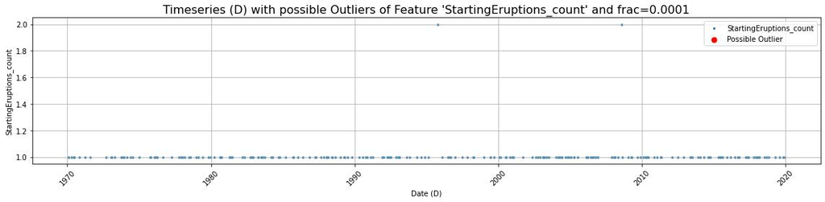

```
------------------------------------------------------------------------------------------------------------------------
Outliers Detection of Feature 'ActiveEruptions' and frac=0.0001
There are 0 possible outliers.
```

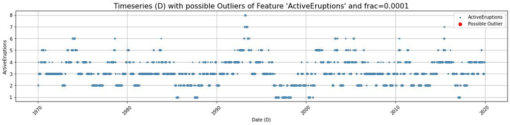

```
------------------------------------------------------------------------------------------------------------------------
Outliers Detection of Feature 'ExplosivityIndexMax_max' and frac=0.0001
There are 2 possible outliers.
```

| Date | StartingEruptions_count | ExplosivityIndexMax_max | DailyEruptedVolume_sum | ActiveEruptions | is_outlier |
| --- | --- | --- | --- | --- | --- |
| 1981-05-15 | 1.0 | 4.0 | 3.453039e+05 | 3 | -1 |
| 1991-04-02 | 1.0 | 6.0 | 3.246753e+08 | 4 | -1 |

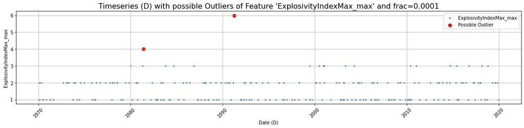

```
------------------------------------------------------------------------------------------------------------------------
Outliers Detection of Feature 'DailyEruptedVolume_sum' and frac=0.0001
There are 0 possible outliers.
```

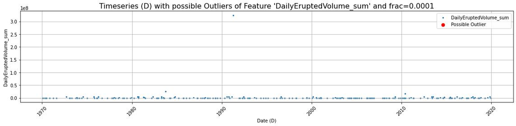

```python
settings_list = [
    {
        "column_to_analyze": ['StartingEruptions_count'],
        "outliers_fraction": 0.0001,
        "log_axis": False
    },{
        "column_to_analyze": ['ActiveEruptions'],
        "outliers_fraction": 0.0001,
        "log_axis": False
    },{
        "column_to_analyze": ['ExplosivityIndexMax_max'],
        "outliers_fraction": 0.0001,
        "log_axis": False
    },{
        "column_to_analyze": ['DailyEruptedVolume_sum'],
        "outliers_fraction": 0.0001,
        "log_axis": False
    }
]

print("-"*120)
for settings in settings_list:
    column_to_analyze = settings["column_to_analyze"]
    outliers_fraction = settings["outliers_fraction"]
    log_axis = settings["log_axis"]
    analyze_outliers(erupt_ts_daily_multi, column_to_analyze, outliers_fraction, log_axis)
```

### Re-sampling timeseries

```python
## Generate resampled timeseries

# resample to weekly frequency and aggregate
erupt_ts_weekly_multi = erupt_ts_daily_multi.resample('W').agg({
    'StartingEruptions_count': 'mean',
    'ActiveEruptions': 'mean',
    'ExplosivityIndexMax_max': 'max',
    'DailyEruptedVolume_sum': 'sum'
})
print("Weekly")
display(erupt_ts_weekly_multi)

# resample to monthly frequency and aggregate
erupt_ts_monthly_multi = erupt_ts_daily_multi.resample('M').agg({
    'StartingEruptions_count': 'mean',
    'ActiveEruptions': 'mean',
    'ExplosivityIndexMax_max': 'max',
    'DailyEruptedVolume_sum': 'sum'
})
print("Monthly")
display(erupt_ts_monthly_multi)

# resample to yearly frequency and aggregate
erupt_ts_yearly_multi = erupt_ts_daily_multi.resample('Y').agg({
    'StartingEruptions_count': 'sum',
    'ActiveEruptions': 'mean',
    'ExplosivityIndexMax_max': 'max',
    'DailyEruptedVolume_sum': 'sum'
})
print("Yearly")
display(erupt_ts_yearly_multi)
```

```
Weekly
```

| Date | StartingEruptions_count | ActiveEruptions | ExplosivityIndexMax_max | DailyEruptedVolume_sum |
| --- | --- | --- | --- | --- |
| 1970-01-04 | NaN | 2.000000 | NaN | 0.000000 |
| 1970-01-11 | NaN | 2.000000 | NaN | 0.000000 |
| 1970-01-18 | NaN | 2.000000 | NaN | 0.000000 |
| 1970-01-25 | NaN | 2.000000 | NaN | 0.000000 |
| 1970-02-01 | 1.0 | 3.428571 | 2.0 | 52637.889688 |
| ... | ... | ... | ... | ... |
| 2019-12-08 | 1.0 | 3.571429 | 1.0 | 374.531835 |
| 2019-12-15 | NaN | 4.000000 | NaN | 0.000000 |
| 2019-12-22 | NaN | 4.000000 | NaN | 0.000000 |
| 2019-12-29 | NaN | 4.000000 | NaN | 0.000000 |
| 2020-01-05 | NaN | 4.000000 | NaN | 0.000000 |

2610 rows × 4 columns

```
Monthly
```

| Date | StartingEruptions_count | ActiveEruptions | ExplosivityIndexMax_max | DailyEruptedVolume_sum |
| --- | --- | --- | --- | --- |
| 1970-01-31 | 1.0 | 2.290323 | 2.0 | 5.263789e+04 |
| 1970-02-28 | NaN | 3.000000 | NaN | 0.000000e+00 |
| 1970-03-31 | NaN | 3.000000 | NaN | 0.000000e+00 |
| 1970-04-30 | 1.0 | 3.333333 | 2.0 | 5.681818e+03 |
| 1970-05-31 | NaN | 4.000000 | NaN | 0.000000e+00 |
| ... | ... | ... | ... | ... |
| 2019-08-31 | 1.0 | 4.612903 | 2.0 | 2.631579e+05 |
| 2019-09-30 | NaN | 4.000000 | NaN | 0.000000e+00 |
| 2019-10-31 | NaN | 3.387097 | NaN | 0.000000e+00 |
| 2019-11-30 | 1.0 | 3.033333 | 2.0 | 5.000000e+06 |
| 2019-12-31 | 1.0 | 3.870968 | 1.0 | 3.745318e+02 |

600 rows × 4 columns

```
Yearly
```

| Date | StartingEruptions_count | ActiveEruptions | ExplosivityIndexMax_max | DailyEruptedVolume_sum |
| --- | --- | --- | --- | --- |
| 1970-12-31 | 6.0 | 3.704110 | 2.0 | 8.028957e+04 |
| 1971-12-31 | 2.0 | 3.005479 | 1.0 | 2.000000e+05 |
| 1972-12-31 | 1.0 | 2.713115 | 2.0 | 5.000000e+06 |
| 1973-12-31 | 6.0 | 4.334247 | 2.0 | 4.786957e+05 |
| 1974-12-31 | 4.0 | 3.983562 | 2.0 | 5.116270e+06 |
| ... | ... | ... | ... | ... |
| 2015-12-31 | 6.0 | 4.279452 | 3.0 | 2.519202e+06 |
| 2016-12-31 | 4.0 | 3.103825 | 3.0 | 6.425982e+06 |
| 2017-12-31 | 5.0 | 2.131507 | 2.0 | 5.857038e+06 |
| 2018-12-31 | 6.0 | 3.539726 | 3.0 | 1.023989e+06 |
| 2019-12-31 | 4.0 | 3.715068 | 2.0 | 5.275215e+06 |

50 rows × 4 columns

```
------------------------------------------------------------------------------------------------------------------------
Outliers Detection of Feature 'StartingEruptions_count' and frac=0.0001
There are 0 possible outliers.
```

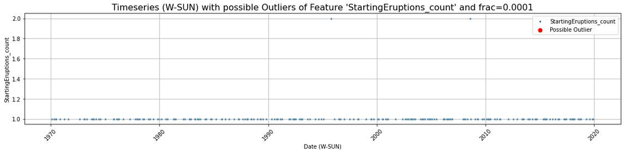

```
------------------------------------------------------------------------------------------------------------------------
Outliers Detection of Feature 'StartingEruptions_count' and frac=0.0001
There are 1 possible outliers.
```

| Date | StartingEruptions_count | ActiveEruptions | ExplosivityIndexMax_max | DailyEruptedVolume_sum | is_outlier |
| --- | --- | --- | --- | --- | --- |
| 1995-10-31 | 2.0 | 4.16129 | 1.0 | 7269.076305 | -1 |

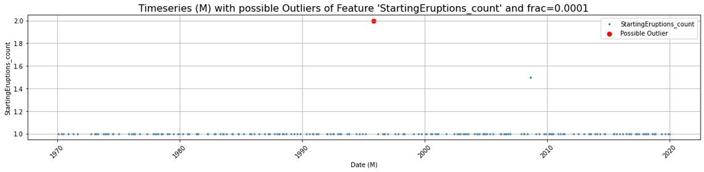

```
------------------------------------------------------------------------------------------------------------------------
Outliers Detection of Feature 'StartingEruptions_count' and frac=0.0001
There are 1 possible outliers.
```

| Date | StartingEruptions_count | ActiveEruptions | ExplosivityIndexMax_max | DailyEruptedVolume_sum | is_outlier |
| --- | --- | --- | --- | --- | --- |
| 2006-12-31 | 9.0 | 3.167123 | 2.0 | 463301.46327 | -1 |

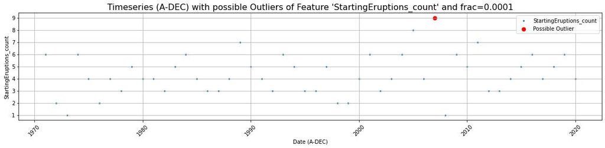

```
------------------------------------------------------------------------------------------------------------------------
Outliers Detection of Feature 'ActiveEruptions' and frac=0.0001
There are 0 possible outliers.
```

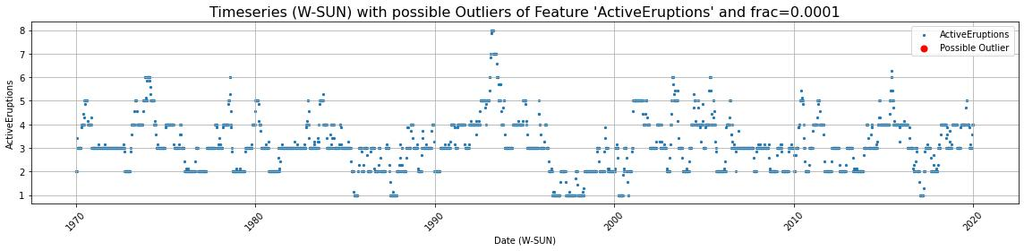

```
------------------------------------------------------------------------------------------------------------------------
Outliers Detection of Feature 'ActiveEruptions' and frac=0.0001
There are 1 possible outliers.
```

| Date | StartingEruptions_count | ActiveEruptions | ExplosivityIndexMax_max | DailyEruptedVolume_sum | is_outlier |
| --- | --- | --- | --- | --- | --- |
| 1993-03-31 | NaN | 8.0 | NaN | 0.0 | -1 |

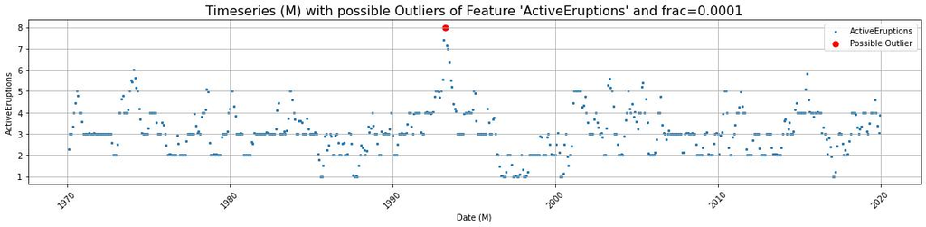

```
------------------------------------------------------------------------------------------------------------------------
Outliers Detection of Feature 'ActiveEruptions' and frac=0.0001
There are 1 possible outliers.
```

| Date | StartingEruptions_count | ActiveEruptions | ExplosivityIndexMax_max | DailyEruptedVolume_sum | is_outlier |
| --- | --- | --- | --- | --- | --- |
| 1993-12-31 | 5.0 | 5.638356 | 2.0 | 602409.186989 | -1 |

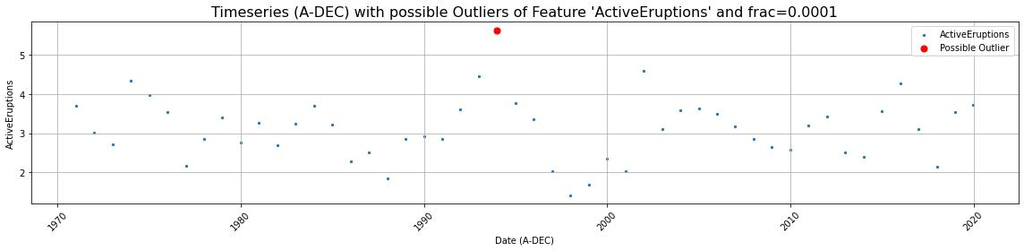

```
------------------------------------------------------------------------------------------------------------------------
Outliers Detection of Feature 'ExplosivityIndexMax_max' and frac=0.0001
There are 1 possible outliers.
```

| Date | StartingEruptions_count | ActiveEruptions | ExplosivityIndexMax_max | DailyEruptedVolume_sum | is_outlier |
| --- | --- | --- | --- | --- | --- |
| 1991-04-07 | 1.0 | 3.857143 | 6.0 | 3.246753e+08 | -1 |

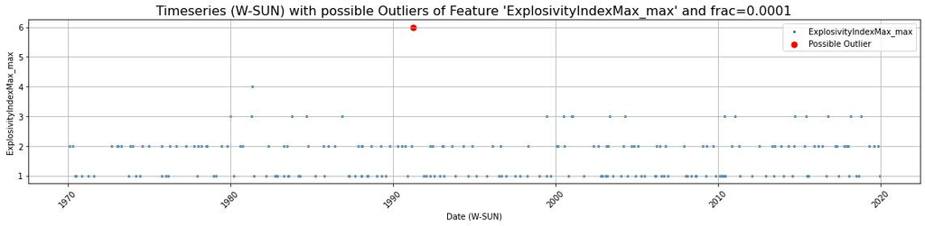

```
------------------------------------------------------------------------------------------------------------------------
Outliers Detection of Feature 'ExplosivityIndexMax_max' and frac=0.0001
There are 1 possible outliers.
```

| Date | StartingEruptions_count | ActiveEruptions | ExplosivityIndexMax_max | DailyEruptedVolume_sum | is_outlier |
| --- | --- | --- | --- | --- | --- |
| 1991-04-30 | 1.0 | 3.966667 | 6.0 | 3.246753e+08 | -1 |

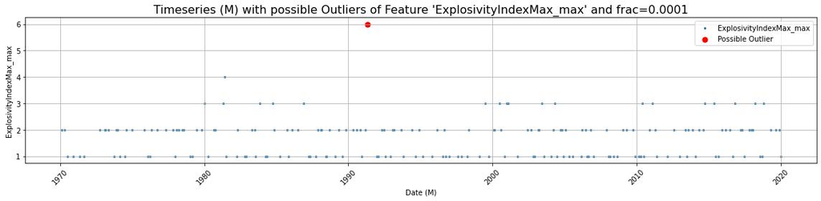

```
------------------------------------------------------------------------------------------------------------------------
Outliers Detection of Feature 'ExplosivityIndexMax_max' and frac=0.0001
There are 1 possible outliers.
```

| Date | StartingEruptions_count | ActiveEruptions | ExplosivityIndexMax_max | DailyEruptedVolume_sum | is_outlier |
| --- | --- | --- | --- | --- | --- |
| 1991-12-31 | 3.0 | 3.619178 | 6.0 | 3.296760e+08 | -1 |

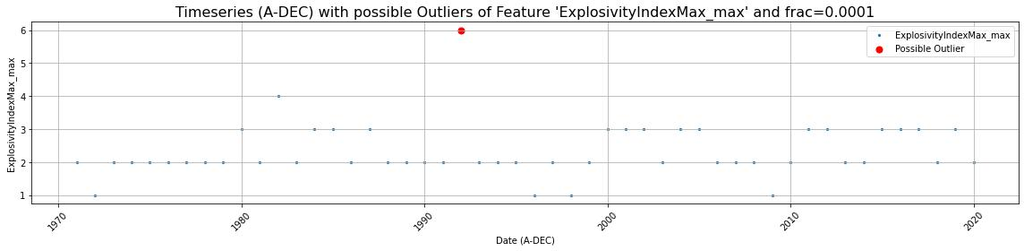

```
------------------------------------------------------------------------------------------------------------------------
Outliers Detection of Feature 'DailyEruptedVolume_sum' and frac=0.0001
There are 1 possible outliers.
```

| Date | StartingEruptions_count | ActiveEruptions | ExplosivityIndexMax_max | DailyEruptedVolume_sum | is_outlier |
| --- | --- | --- | --- | --- | --- |
| 1991-04-07 | 1.0 | 3.857143 | 6.0 | 3.246753e+08 | -1 |

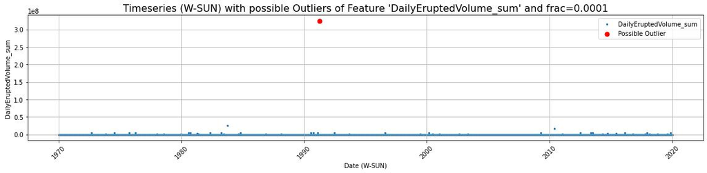

```
------------------------------------------------------------------------------------------------------------------------
Outliers Detection of Feature 'DailyEruptedVolume_sum' and frac=0.0001
There are 1 possible outliers.
```

| Date | StartingEruptions_count | ActiveEruptions | ExplosivityIndexMax_max | DailyEruptedVolume_sum | is_outlier |
| --- | --- | --- | --- | --- | --- |
| 1991-04-30 | 1.0 | 3.966667 | 6.0 | 3.246753e+08 | -1 |

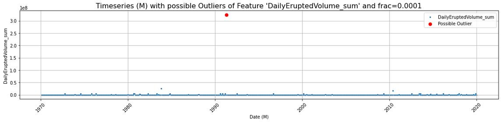

```
------------------------------------------------------------------------------------------------------------------------
Outliers Detection of Feature 'DailyEruptedVolume_sum' and frac=0.0001
There are 1 possible outliers.
```

| Date | StartingEruptions_count | ActiveEruptions | ExplosivityIndexMax_max | DailyEruptedVolume_sum | is_outlier |
| --- | --- | --- | --- | --- | --- |
| 1991-12-31 | 3.0 | 3.619178 | 6.0 | 3.296760e+08 | -1 |

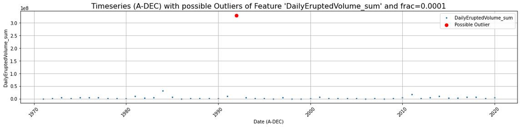

```python
print("-"*120)
for settings in settings_list:
    column_to_analyze = settings["column_to_analyze"]
    outliers_fraction = settings["outliers_fraction"]
    log_axis = settings["log_axis"]
    analyze_outliers(erupt_ts_weekly_multi, column_to_analyze, outliers_fraction, log_axis)
    analyze_outliers(erupt_ts_monthly_multi, column_to_analyze, outliers_fraction, log_axis)
    analyze_outliers(erupt_ts_yearly_multi, column_to_analyze, outliers_fraction, log_axis)
```

## Check timeseries dates according to timespan

All data must be within the set timeframe, which is otherwise being corrected.

```python
# set all timeseries names for saving and loading
ts_names = ["erupt_ts_daily_multi", "erupt_ts_weekly_multi", "erupt_ts_monthly_multi", "erupt_ts_yearly_multi"]

# show timeseries summaries by defining a list of the datframe names
# and running a loop over this list to show the timeseries summaries
# by evaluating the names and getting the summaries as a dictionary
for name in ts_names:
    ts = eval(name)
    summary = summarize_time_series(ts)  # Call the function
    print(f"Timeseries summary for {name}:\n{summary}, Freq: {pd.infer_freq(ts.index)}")
    print(f"Type: {type(ts)}\n")
```

```
Timeseries summary for erupt_ts_daily_multi:
{'number_of_entries': 18262, 'first_date': Timestamp('1970-01-01 00:00:00'), 'last_date': Timestamp('2019-12-31 00:00:00'), 'ts_type': <class 'pandas.core.frame.DataFrame'>, 'ts_freq_index': 'D', 'ts_freq_inferred': 'D'}, Freq: D
Type: <class 'pandas.core.frame.DataFrame'>

Timeseries summary for erupt_ts_weekly_multi:
{'number_of_entries': 2610, 'first_date': Timestamp('1970-01-04 00:00:00', freq='W-SUN'), 'last_date': Timestamp('2020-01-05 00:00:00', freq='W-SUN'), 'ts_type': <class 'pandas.core.frame.DataFrame'>, 'ts_freq_index': <Week: weekday=6>, 'ts_freq_inferred': 'W-SUN'}, Freq: W-SUN
Type: <class 'pandas.core.frame.DataFrame'>

Timeseries summary for erupt_ts_monthly_multi:
{'number_of_entries': 600, 'first_date': Timestamp('1970-01-31 00:00:00', freq='M'), 'last_date': Timestamp('2019-12-31 00:00:00', freq='M'), 'ts_type': <class 'pandas.core.frame.DataFrame'>, 'ts_freq_index': <MonthEnd>, 'ts_freq_inferred': 'M'}, Freq: M
Type: <class 'pandas.core.frame.DataFrame'>

Timeseries summary for erupt_ts_yearly_multi:
{'number_of_entries': 50, 'first_date': Timestamp('1970-12-31 00:00:00', freq='A-DEC'), 'last_date': Timestamp('2019-12-31 00:00:00', freq='A-DEC'), 'ts_type': <class 'pandas.core.frame.DataFrame'>, 'ts_freq_index': <YearEnd: month=12>, 'ts_freq_inferred': 'A-DEC'}, Freq: A-DEC
Type: <class 'pandas.core.frame.DataFrame'>
```

All start- and end-dates of all timeseries are within the set timeframe or set to the next available date according to the timeseries generation and re-indexing.

## Save data

### Multivariate timeseries

```python
# iterate over the timeseries names to save, eval the names and call save_timeseries function, part 1
for name in ts_names:
    ts = eval(name)
    save_timeseries(
        data_file=f"{name}.csv",
        data_dir=data_ts_dir_cluster,
        data_set=ts,
        append_datetime=False,
        overwrite_file=True
    )

# iterate over the timeseries names to save, eval the names and call save_timeseries function, part 2
for name in ts_names:
    ts = eval(name)
    save_timeseries(
        data_file=f"{name}.csv",
        data_dir=data_ts_dir_cluster,
        data_set=ts,
        append_datetime=True,
        overwrite_file=False
    )
```

```
2025-01-26 21:15:30,566 - INFO - save_dataset: Timeseries saved successfully to 'data/scope/reclustered_1000/cluster_Cluster_0/erupt_ts_daily_multi.csv'.
2025-01-26 21:15:30,580 - INFO - save_dataset: Timeseries saved successfully to 'data/scope/reclustered_1000/cluster_Cluster_0/erupt_ts_weekly_multi.csv'.
2025-01-26 21:15:30,585 - INFO - save_dataset: Timeseries saved successfully to 'data/scope/reclustered_1000/cluster_Cluster_0/erupt_ts_monthly_multi.csv'.
2025-01-26 21:15:30,587 - INFO - save_dataset: Timeseries saved successfully to 'data/scope/reclustered_1000/cluster_Cluster_0/erupt_ts_yearly_multi.csv'.
2025-01-26 21:15:30,661 - INFO - save_dataset: Timeseries saved successfully to 'data/scope/reclustered_1000/cluster_Cluster_0/erupt_ts_daily_multi_250126-211530.csv'.
2025-01-26 21:15:30,674 - INFO - save_dataset: Timeseries saved successfully to 'data/scope/reclustered_1000/cluster_Cluster_0/erupt_ts_weekly_multi_250126-211530.csv'.
2025-01-26 21:15:30,679 - INFO - save_dataset: Timeseries saved successfully to 'data/scope/reclustered_1000/cluster_Cluster_0/erupt_ts_monthly_multi_250126-211530.csv'.
2025-01-26 21:15:30,681 - INFO - save_dataset: Timeseries saved successfully to 'data/scope/reclustered_1000/cluster_Cluster_0/erupt_ts_yearly_multi_250126-211530.csv'.
```

### Save enriched datasets

```python
# save earthquake dataset
save_dataset(data_file = "volcanoes_enriched.csv",
             data_dir = data_dir_cluster,
             data_set = volcanoes_enriched,
             append_datetime=False,
             overwrite_file=True
            )

# save earthquake dataset
save_dataset(data_file = "volcanoes_enriched.csv",
             data_dir = data_dir_cluster,
             data_set = volcanoes_enriched,
             append_datetime=True,
             overwrite_file=False
            )

# save earthquake dataset
save_dataset(data_file = "eruptions_enriched.csv",
             data_dir = data_dir_cluster,
             data_set = eruptions_enriched,
             append_datetime=False,
             overwrite_file=True
            )

# save earthquake dataset
save_dataset(data_file = "eruptions_enriched.csv",
             data_dir = data_dir_cluster,
             data_set = eruptions_enriched,
             append_datetime=True,
             overwrite_file=False
            )
```

```
2025-01-26 21:15:30,689 - INFO - save_dataset: Data saved successfully to 'data/scope/reclustered_1000/cluster_Cluster_0/volcanoes_enriched.csv'.
2025-01-26 21:15:30,692 - INFO - save_dataset: Data saved successfully to 'data/scope/reclustered_1000/cluster_Cluster_0/volcanoes_enriched_250126-211530.csv'.
2025-01-26 21:15:30,696 - INFO - save_dataset: Data saved successfully to 'data/scope/reclustered_1000/cluster_Cluster_0/eruptions_enriched.csv'.
2025-01-26 21:15:30,700 - INFO - save_dataset: Data saved successfully to 'data/scope/reclustered_1000/cluster_Cluster_0/eruptions_enriched_250126-211530.csv'.
```

## End of script

```python
# log the end of this script
logging.info(f"End of script '{script_name}'.")
```

```
2025-01-26 21:15:30,704 - INFO - End of script '31_create_volcanic_eruption_timeseries.ipynb'.
```

## Appendix

```python
%%js

// -------------------------------------------
// What are the headings of this document?
// --> Get a better overview of the structure.
// -------------------------------------------

function listHeadings() {
    let headings = [];
    let cells = Jupyter.notebook.get_cells();

    cells.forEach((cell) => {
        if (cell.cell_type == 'markdown') {
            let text = cell.get_text();
            let lines = text.split('\n');

            lines.forEach((line) => {
                let match = line.match(/^(#+)\s+(.*)/);
                if (match) {
                    headings.push({
                        level: match[1].length, // Number of # symbols indicates the heading level
                        text: match[2].trim()
                    });
                }
            });
        }
    });
    return headings;
}

let headings = listHeadings();
headings.forEach((heading) => {
    let markdown = `${'#'.repeat(heading.level)} ${heading.text}`;
    element.append(`${markdown}<br>`);
});
```

## Save notebook as experimentation protocol

```python
# save notebook as a experimentation protocol
time.sleep(2)
display(Javascript('IPython.notebook.save_checkpoint();'))
time.sleep(2)
save_notebook_as_html(script_name, data_dir_cluster)
```